# Introduzione a GGPLOT2

Matteo Miotto

2021-03-18

Ggplot2 è un utilissimo pacchetto grafico che ci permette di ricreare praticamente qualunque tipologia di grafico, esattamente nel modo in cui l’abbiamo pensato, grazie ad una vasta gamma di funzioni di personalizzazione e di pacchetti aggiuntivi compatibili. In questo post partiamo vedendo le basi di questo pacchetto, ovvero come creare grafici basilari analizzando le 3 componenti necessarie per la creazione di un grafico con Ggplot2.

Quando parlo di “componenti”, mi riferisco a tipologie di comandi che bisogna inserire per la costruzione di un grafico con questo pacchetto. Queste componenti sono in tutto 8:

Data

Mapping

Geometries

Statistics

Scales

Facets

Coordinates

Theme

Oggi ci focalizzeremo sulle prime 3, in quanto sono le uniche 3 di cui ggplot2 ha bisogno di informazioni; le altre infatti possono essere omesse in quanto hanno già dei valori di default. Di seguito una versione minimal del comando da utilizzare per creare un grafico base con ggplot2:

```r
ggplot(data = <data>) +
  <geom_function>(mapping = aes(<mapping>))
```

Spesso `data =` e `mapping =` sono sottointesi.

# Data

Partiamo dalla parte più semplice, ovvero *data*. A <data> va sostituito il dafarame/tibble da cui prendere i dati. In questo post useremo il dataframe standard di R *mtcars*.

## Geometries

Il secondo comando da definire è quello legato alle geometrie, ovvero alla forme che dovranno assumere i dati nel grafico. Le classiche geometri sono `geom_point()` per gli scatter plot, `geom_bar()` e `geom_col()` per i barplot, `geom_boxplot()` per i boxplot e via dicendo. Le geometrie sono davvero tante, e sono legate anche al concetto di *statistics*. Verranno affrontate le relazioni in un post dedicato. Di seguito un paio di esempi giusto per far vedere vari tipi di `geom_`.

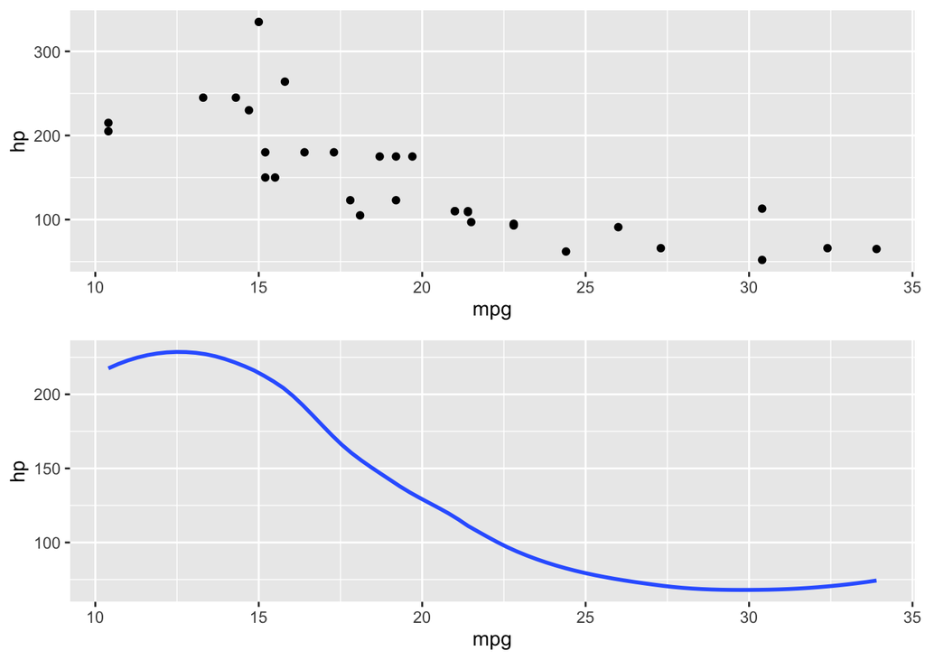

Stessi dati ma geom_ diverse. In alto geom_point(), in basso geom_smooth()

Una cosa interessante e molto utile di ggplot2 è la facilità con cui si possono usare più geometrie sugli stessi dati (o su dati diversi) in un solo plot. Tutte le caratteristiche comuni si mettono dentro `ggplot()`, mentre le caratteristiche peculiari si mettono dentro le geometrie. Per esempio, combinando i due plot di sopra:

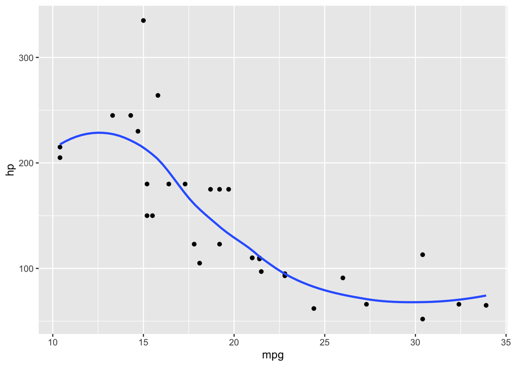

Combinazione di due geometrie nello stesso grafico

```r
ggplot(mtcars, aes(x = mpg, y = hp)) +
  geom_point() +
  geom_smooth(se = F)
```

## Mapping

Tramite il mapping noi andiamo a dire a ggplot quali variabili plottare e a definire altri parametri estetici come colore, riempimento, forma ecc. Vediamo subito tramite qualche esempio come funziona:

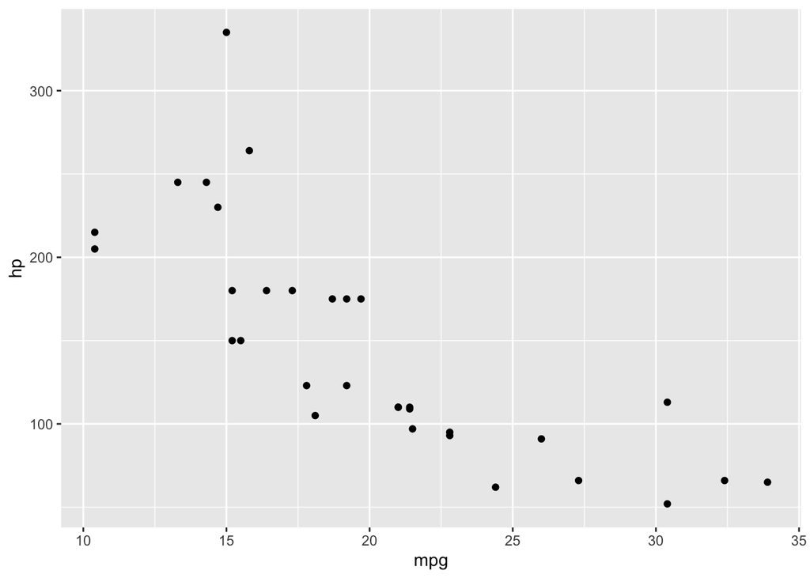

Scatter plot base

```r
ggplot(data = mtcars) +
  geom_point(mapping = aes(x = mpg, y = hp))
```

In questo esempio c’era uno scatter plot molto semplice, in cui sono state mappate in x e y, dentro `aes()`, le colonne `mpg` e `hp` del dataset `mtcars`.

### Cambiare estetiche a tutto il grafico

Se vogliamo cambiare estetiche quali colori, forme ecc di tutto ciò che è plottato bisogna mettere queste specifiche al di fuori di`aes()`. Per esempio, se si vogliono cambiare forma e colore dei punti plottati nel grafico precente, si procede così:

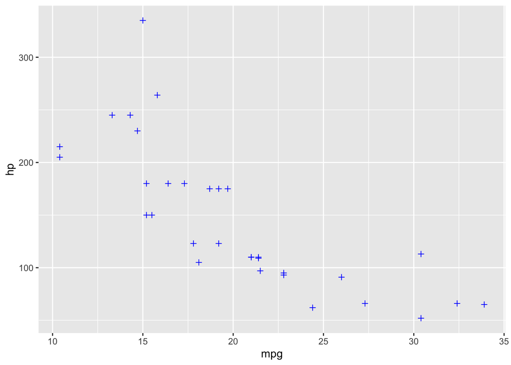

Scatter plot a cui sono stati cambiati forma e colore dei punti

```r
ggplot(data = mtcars) +
  geom_point(mapping = aes(x = mpg, y = hp), color = "blue", shape = 3)
```

Ci sono varie estetiche nel grafico che si possono modificare, ogni <geom> ha la sua, per questo non verranno analizzate nel dettaglio in questo post.

### Cambiare estetiche in base ad un’altra variabile

Le stesse estetiche di sopra possono essere cambiate anche in base ad una variabile/condizione. In questo caso si mappano dentro `aes()` in quanto non tutte le osservazioni avranno le stesse caratteristiche estetiche nel grafico. *Esempio* Si vogliano evidenziare in uno scatter plot tra mpg e hp, quali vetture pesano meno di 3.250.

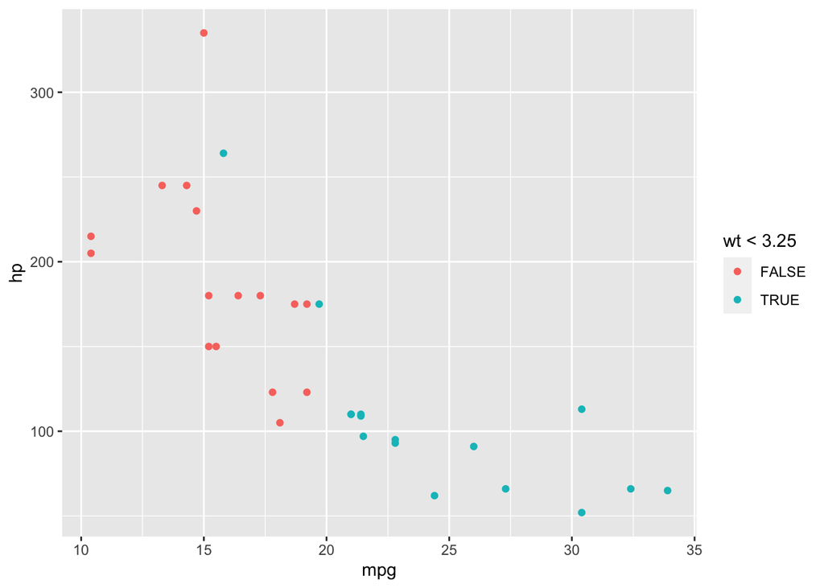

Scatter plot con colorazioni diverse in base al peso dell’auto

```r
ggplot(data = mtcars) +
  geom_point(mapping = aes(x = mpg, y = hp, color = wt < 3.25))
```

Come si può vedere, è comparsa una legenda che ci aiuta a capire lo schema grafico utilizzato.

Questo mappamento può essere fatto anche utilizzando una variabile categorica (o anche continua):

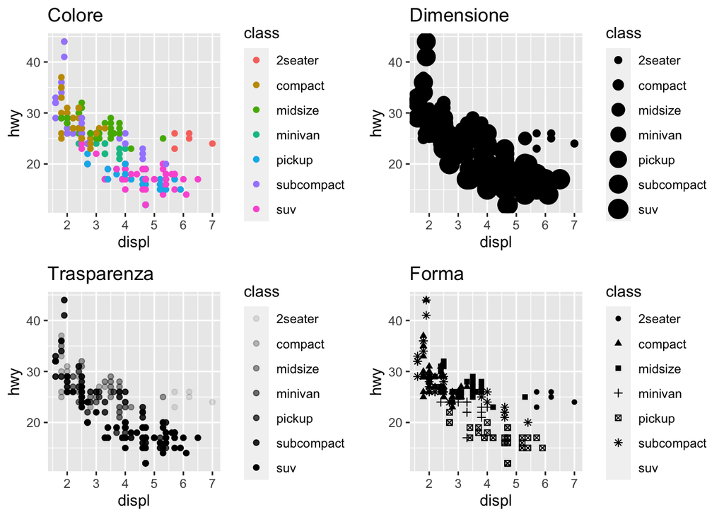

Quattro esempi di come si possono evidenzire i punti in base ad una variabile categorica: colore, dimensione, trasparenza e forma

Ora abbiamo visto i comandi base per creare un plot con il pacchetto *ggplot2*, seguiranno post in cui si entrerà nel merito delle altre componenti, con esempi e spiegazioni più dettagliate.